# Lecture 4：異質性のある需要 — random coefficient logit と合併分析

計量経済学II

作者

Kei Ikegami

**重要この講義で押さえたいこと**

- random coefficient logit では、**係数を消費者ごとに変える**ことで、ネストを事前に決めずに代替関係を柔軟に表現できる。
- シェアの式には積分が残るため、**モンテカルロ積分**で計算する。第2回で学んだ、シミュレーションで確率を求める方法を使う。
- 推定には、BLPの手続きを簡略化した **ミニBLP** を使う。内側で縮小写像を使って $\delta$ を解き、中間でIV回帰を行い、外側でGMMの目的関数を最小化する。この手順を自分で実装すると、pyblp の計算も理解しやすくなる。
- 供給側（Bertrand-Nash）を加えると、推定した需要から **合併後の価格上昇**を計算できる。次回のゲスト講義で扱う、公正取引委員会の合併審査にもつながる。
- 品質順位が共通な場合と、好みによって順位が違う場合を3人の買い物で比べる。**属性への評価を人ごとに変える**と、現在の販売数が同じでも値上げ後の需要は変わり得る。

## 前回とのつながり・今回のゴール

第3回では、第2回で学んだ logit を使って需要を推定する際の、2つの問題を扱った。一つは、どの商品からどの商品へ需要が移るかをモデルが強く制約してしまうこと。もう一つは、価格が分析者には見えない需要ショックに反応して決まる、価格の内生性である。今回は、この両方の話を引き継ぐ。

まず、代替関係の問題を振り返ろう。plain logit には IIA（無関係な選択肢からの独立性）があり、他の価格や属性を固定して財3だけを値上げすると、財1と財2の需要の増加分の比は、両者の元のシェア比で決まる。財1の方が財3に似ているとしても、その近さを別に反映できない。前回の nested logit では、同じネストに属する財の効用ショックに相関を許すことで、この制約を緩めた。ただし、**どの財を同じネストに入れるかは分析者が事前に決める**必要があり、同じネスト内の2財のシェア比にはIIAが残る。

今回は、ネストを指定する代わりに、**属性への評価や価格への反応を表す係数を、消費者ごとに変える**。これまでも、効用ショックを通じて人による好みの違いを表していた。新しく加えるのは、例えば甘さを評価する係数そのものが人によって違い、甘いコーヒーを好む人は複数の甘い商品を高く評価する、という関係である。価格への反応にも人による違いを認める。こうしたモデルを random coefficient logit と呼ぶ。

次に、価格の内生性である。前回は、**Berry反転でシェアから平均効用を取り出し、その式にIVを使う**ことで対処した。反転は需要ショックを取り出せる形を作るための操作であり、価格と需要ショックの相関に対処するには、妥当な操作変数が必要だった。係数を消費者ごとに変えても、この内生性の問題は残る。

そこで今回は、random coefficient logit でも同じ推定の考え方を使いたい。ただし、消費者ごとの選択確率を平均してシェアを求めるため、前回の logit のようにシェアの対数差だけで平均効用を取り出すことはできない。好みのばらつきを表すパラメータを仮に決め、観測シェアを再現する平均効用を数値計算で逆算する。その上で、取り出した需要ショックと操作変数が無相関になる条件を使って推定する。これが、今回学ぶ**BLPの推定方法**につながる。

前半では、係数の異質性が代替関係をどう変えるかを確かめ、このモデルを推定する。後半では、推定した需要に企業の価格設定行動を加え、**合併したら価格がどれだけ上がるか**を計算する。第5回のゲスト講義で扱う、公正取引委員会の合併審査を理解するための準備でもある。

今回は計算の手順が少し長い。まずはそれぞれの段階で何を求めているかを押さえ、細かい実装は必要に応じて戻って確認しよう。

## 1. なぜ係数を消費者ごとに変えるのか

コンビニにブラック、微糖、カフェオレの3種類が並んでいるとする。消費者はどれかを買うか、「買わない」（outside option）を選ぶ。ここで微糖が10円値上げされたらどうなるだろうか。plain logit では、微糖からブラックとカフェオレへ移る需要の比率は、両者の市場シェアの比で決まる。

しかし、微糖を選ぶ人の多くが甘さを好むなら、値上げ後の候補としてブラックよりカフェオレを高く評価するかもしれない。このような代替を表す一つの方法が、**人によって甘さの好みが違う**ことをモデルに入れることである。第2回の $x_j'\beta$ の $\beta$ を、人ごとの $\beta_i$ に変える。以下では、その意味を3人の買い物で確かめる。どの属性の係数をどう分布させるかが代替パターンを決めるので、係数を動かせば任意の「近さ」が自動的に再現されるわけではない。

価格への反応も、人によって違う。例えば、所得の高い管理職は10円の値上げをあまり気にしない（$\alpha_i$ が小さい）が、学生は気にする（$\alpha_i$ が大きい）、と考えてみよう。この異質性を入れると、もともと価格をあまり気にしない人ほど高い財を買いやすくなる。こうした選択（セレクション）によって、高価格帯の弾力性も plain logit の予測とは変わってくる。

**ノートビジネスの現場で：自社ラインナップのカニバリゼーション**

新商品を出すときには、自社のどの既存商品から客が移るかも知りたい。これがカニバリゼーション（cannibalization）の問題である。plain logit では、どの商品から移るかはシェアの比率で決まってしまう。しかし「濃いめのカフェオレ」を発売したなら、ブラックよりも微糖や既存のカフェオレから客が移りやすいと考えられる。random coefficient logit では、属性への好みの違いを使って、どの自社製品の需要がどれだけ減るかを予測する。この予測は、価格改定や品揃え（assortment）の最適化にも使われる。

### 品質の順位と好みの違いを3人の例で比べる

製品の違いを、**価格を同じにそろえたとき、消費者の製品順位が一致するか**という観点から整理しよう。同じ価格なら全員が同じ品質順位で評価する場合を**垂直的差別化**、好みによって製品の順位が異なる場合を**水平的差別化**と呼ぶ。

ここでは、両者からどんな需要が生まれるかを、3人の買い物の例で確かめよう。いずれも説明用の架空の市場であり、効用を「評価額−価格」として円単位で測る。買わない効用は0とし、ランダム項は一旦省く。後でこの例を random coefficient logit につなげる。

#### 垂直的差別化：同じ価格なら全員が高品質を好む

Aは品質1、Bは品質2のコーヒーとする。品質1単位に払ってよいと思う金額が、3人それぞれ120円、160円、220円だとしよう。BはAの2倍の品質なので、それぞれの評価額も2倍になる。

| 消費者 | Aの評価額 | Bの評価額 | Aが100円、Bが250円のときの効用と選択 | Bだけ300円にしたときの効用と選択 |
| --- | --- | --- | --- | --- |
| 1人目 | 120円 | 240円 | A：20、B：−10 → **A** | A：20、B：−60 → **A** |
| 2人目 | 160円 | 320円 | A：60、B：70 → **B** | A：60、B：20 → **A** |
| 3人目 | 220円 | 440円 | A：120、B：190 → **B** | A：120、B：140 → **B** |

例えば2人目は、値上げ前には $320-250=70$ が $160-100=60$ より大きいのでBを買う。値上げ後にはBの効用が $320-300=20$ に下がるのでAに移る。3人の選択を数えると、**需要はAが1本・Bが2本から、Aが2本・Bが1本へ変わる**。

AもBも100円だったら、3人ともBを選ぶ。**同じ価格なら、全員が同じ品質順位で製品を評価する**のが、この垂直的差別化の例である。好みが完全に同じという意味ではなく、追加の品質にいくら払うかは人によって異なる。品質を $z_j$、人 $i$ の品質1単位への評価を $w_i>0$ とすれば、効用は $u_{ij}=w_i z_j-p_j$ と書ける。すでにこのモデルにも、品質への支払意思額の異質性がある。

#### 水平的差別化：同じ価格でも好きな製品が違う

今度はAを「苦いコーヒー」、Bを「甘いコーヒー」と考える。苦い方が好きな人も、甘い方が好きな人もいる。次の評価額を持つ3人を考えよう。

| 消費者 | Aの評価額 | Bの評価額 | Aが100円、Bが250円のときの効用と選択 | Bだけ300円にしたときの効用と選択 |
| --- | --- | --- | --- | --- |
| 1人目 | 160円 | 80円 | A：60、B：−170 → **A** | A：60、B：−220 → **A** |
| 2人目 | 120円 | 360円 | A：20、B：110 → **B** | A：20、B：60 → **B** |
| 3人目 | 160円 | 400円 | A：60、B：150 → **B** | A：60、B：100 → **B** |

同じ100円にそろえても、1人目はA、2・3人目はBを選ぶ。**同じ価格でも、人によって製品の好ましさの順位が違う**のが、この水平的差別化の例である。

値上げ前の需要は、先ほどと同じAが1本・Bが2本である。しかし、この例ではBを300円にしても2・3人目はBを選び続け、需要は変わらない。同じ現在の販売数を説明できても、好みのモデルが違えば、値上げ後の需要予測は違う。水平的差別化なら必ず価格に反応しにくいという意味ではなく、**現在のシェアだけでは代替関係は決まらない**、という例である。

#### 共通の $\beta$ から $\beta_i$ へ：特性への評価を変える

第2回で学んだ**特性アプローチ（characteristics approach）**では、製品を特徴の束として表した。Aの特徴を「苦味2・甘さ0」、Bを「苦味0・甘さ2」とし、苦味と甘さ1単位への評価額を次のように置くと、上の水平的差別化の表を作れる。

| 消費者 | 苦味1単位への評価 | 甘さ1単位への評価 | Aの評価額 | Bの評価額 |
| --- | --- | --- | --- | --- |
| 1人目 | 80円 | 40円 | $80\times2+40\times0=160$円 | $80\times0+40\times2=80$円 |
| 2人目 | 60円 | 180円 | $60\times2+180\times0=120$円 | $60\times0+180\times2=360$円 |
| 3人目 | 80円 | 200円 | $80\times2+200\times0=160$円 | $80\times0+200\times2=400$円 |

製品属性を $x_j$、人ごとの評価を $\beta_i$ とすれば、評価額は $x_j'\beta_i$、効用は $u_{ij}=x_j'\beta_i-p_j$ である。第2回から変えたのは、**属性への係数そのものを人ごとに変えた**点だ。第2回の共通 $\beta$ の logit でも、$\varepsilon_{ij}$ によって同価格で人ごとの製品順位は異なり得た。したがって、random coefficient を入れて初めて水平的な好みの違いを扱える、ということではない。

では、$\beta_i$ にする利点は何か。例えば、Bと同じく甘さを持つ製品Cも並べたとする。甘さへの評価が高い人では、**同じ甘さの係数がBとCの効用をともに押し上げる**。これにより、観測された属性・価格を固定して人々を比べたとき、製品間の効用に属性を通じた相関が生まれる。独立な $\varepsilon_{ij}$ だけに選択の違いを任せる場合と違い、「甘い製品を好んだ人が、どの別の製品を次の候補として好みやすいか」をモデル化できる。これが、ネストを事前に区切らずに代替関係を柔軟にする仕組みである。[Train (2009), Chapter 6](https://eml.berkeley.edu/books/choice2nd/Ch06_p134-150.pdf) は、random coefficient とこの効用の相関の関係を説明している。

ここまでは3人の評価額をすべて既知とし、円単位の効用に価格係数1を置いた手計算だった。次節では、$\beta_i$ や価格係数 $\alpha_i$ に分布を仮定し、さらに Gumbel の $\varepsilon_{ijt}$ を加える。人ごとには logit の選択確率を計算し、それを人々について平均して市場需要を作る。**上の円単位の評価額を、そのまま後の標準化された logit の係数として用いるわけではない**。

**ノート第1回のBresnahanと、今回のBLPのつながり**

第1回の [Bresnahan (1987)](https://doi.org/10.2307/2098583) も、共通の品質軸と消費者ごとの支払意思額から選択を集計して需要を作っていた。最初の垂直的差別化の表は、その考え方を小さくした説明例であり、論文の推定結果ではない。[Berry, Levinsohn and Pakes (1995)](https://www.its.caltech.edu/~mshum/gradio/papers/BerryLevinsohnPakes1995.pdf) はこの系譜を引き継ぎ、複数の属性とより豊かな好みの分布を使い、観測できない製品属性による価格の内生性も扱う需要推定を発展させた。

したがって、ここでの発展は「Bresnahanの需要関数を捨てて離散選択へ移る」ことではない。**属性から効用を作り、選択を集計して需要を作る**という発想を共有した上で、どの属性を誰がどれだけ評価するかの制約を緩めるのである。垂直・水平という製品の評価の仕方と、logit・nested logit・random coefficient logit というモデルの仕様は、別の区別だと整理しておこう。

## 2. モデル：random coefficient logit

記法は第2回・第3回と同じである。消費者を $i$、財を $j$（$j=0$ は「買わない」という outside option）、市場を $t$ と書く。効用は次のようになる。

$$u_{ijt} = x_{jt}'\beta_i - \alpha_i\, p_{jt} + \xi_{jt} + \varepsilon_{ijt}.$$

これまでの logit との違いは、係数に $i$ の添字が付いたことである。$\varepsilon_{ijt}$ はこれまで通り Type I 極値分布（Gumbel）に従う。$\xi_{jt}$ は分析者には観測できない製品・市場の魅力であり、第3回で価格の内生性を考えるときに使った項である。

属性への評価が人によって違うことを、次の式で表す。

$$\beta_i = \beta + \Sigma^{1/2}\nu_i, \qquad \nu_i \sim N(0, I).$$

$\beta$ は平均的な好み、$\Sigma$ は好みのばらつきを表し、その対角成分が異質性の大きさに対応する。$\nu_i$ は消費者ごとの違いを表す乱数である。

### 価格係数には対数正規分布を使う

価格係数 $\alpha_i$ に正規分布を仮定すると、分布の裾では $\alpha_i < 0$ となる人も出てくる。効用の式には価格がマイナスで入っているので、この人は価格が上がるほど効用が高くなってしまう。そこで、実務でも使われる**対数正規分布**を使い、価格係数が常に正になるようにする。

$$\alpha_i = \exp(\bar\alpha + \sigma\, \nu_i^{p}), \qquad \nu_i^{p} \sim N(0,1).$$

$\bar\alpha$ は **log価格係数の平均**、$\sigma$ はlog価格係数の標準偏差である。元の水準では

$$\operatorname{median}(\alpha_i)=e^{\bar\alpha},\qquad
E[\alpha_i]=e^{\bar\alpha+\sigma^2/2}.$$

したがって、$e^{\bar\alpha}$ は一般には平均価格係数ではない。平均と一致するのは $\sigma=0$ のときだけである。この区別に注意しよう。Nevo (2000) は、こうした符号制約や所得との相互作用など、実装上の論点を整理している。次節では属性と価格の両方の係数を動かして比較するが、後半のミニBLP推定では、計算を簡単にするため価格係数だけに異質性を入れる。

**ノート導出：個人の選択確率から市場シェアへ**

$\nu_i$ を1つ固定すると、その人の係数 $(\beta_i, \alpha_i)$ が決まる。したがって、その人の選択確率には、第2回と同じ **logit の公式**を使える。

$$s_{ijt}(\nu_i) = \frac{\exp(\delta_{jt} + \mu_{ijt})}{1 + \sum_{k=1}^{J}\exp(\delta_{kt} + \mu_{ikt})}.$$

ここで $\alpha_0=E[\alpha_i]=e^{\bar\alpha+\sigma^2/2}$ と置けば、平均効用と個人偏差を

$$\delta_{jt}=x_{jt}'\beta-\alpha_0p_{jt}+\xi_{jt},\qquad
\mu_{ijt}=-(\alpha_i-\alpha_0)p_{jt}+x_{jt}'(\Sigma^{1/2}\nu_i)$$

と分けられる。2式を足せば元の効用 $x_{jt}'\beta-\alpha_i p_{jt}+\xi_{jt}$ に戻る。$\delta$ には $i$ が入らず、$\mu$ が平均ゼロの係数偏差を表す、という対応を確認しておこう。

市場全体のシェアは、この選択確率を $\nu$ の分布で積分して求める。人々について平均するということである。

$$s_{jt}(\delta_{\cdot t}, \sigma) = \int s_{ijt}(\nu)\, dF(\nu).$$

選択確率は $\nu$ の非線形な関数なので、この積分は**閉じた形では書けない**。そこで第2回と同じように、シミュレーションを使う。乱数を $ns$ 人分引き、それぞれの選択確率を計算して平均すれば、積分を近似できる。この方法が**モンテカルロ積分**である。

具体的には、シェアを次のように近似する。

$$s_{jt}(\delta_{\cdot t}, \sigma) \approx \frac{1}{ns}\sum_{r=1}^{ns} \frac{\exp(\delta_{jt} + \mu_{jt}(\nu_r))}{1 + \sum_{k}\exp(\delta_{kt} + \mu_{kt}(\nu_r))}$$

第2回では選択確率をシミュレーションで求めた。ここでは、消費者ごとの選択確率を平均して、市場全体のシェアを計算している。

## 3. シミュレーション1：異質性が代替性を変える

以下の図表でいう「同質」「異質」は、属性・価格への**係数**が全員共通か、人によって違うかを指す。どちらのモデルにも $\varepsilon_{ij}$ はある。

まず「$\sigma=0$（＝ plain logit）」と「$\sigma>0$」で、集計需要曲線と交差弾力性がどう変わるかを、コードで作ったデータで見比べる。3財＋outside の1市場を考える。財1と財2は**属性が近い**（$x$ が近い）ペア、財3は離れた財、という設計にする。価格係数の異質性を変える際は $E[\alpha_i]$ を固定し、平均反応の変化とばらつきの変化を混同しない。

```r
# --- モンテカルロ積分でシェアを計算する関数 ---
# nu_x: 個人の属性選好ショック (ns), nu_p: 価格選好ショック (ns)
# 属性 x への好み beta_i = beta_x + sigma_x * nu_x
# 価格係数 alpha_i = exp(abar + sigma_p * nu_p)  （対数正規で正値保証）
sim_shares <- function(x, p, beta0, beta_x, sigma_x, abar, sigma_p, nu_x, nu_p) {
  ns <- length(nu_x)
  J  <- length(x)
  beta_i  <- beta_x + sigma_x * nu_x          # (ns) 属性選好
  alpha_i <- exp(abar + sigma_p * nu_p)       # (ns) 価格係数（正）
  # 効用 v[i,j] = beta0 + beta_i * x_j - alpha_i * p_j
  V <- outer(beta_i, x) - outer(alpha_i, p)   # (ns x J)
  V <- sweep(V, 2, rep(beta0, J), "+")        # 定数項を各財に足す
  eV <- exp(V)
  denom <- 1 + rowSums(eV)                     # outside の効用は 0 -> exp(0)=1
  s_ij <- eV / denom                           # (ns x J) 個人選択確率
  colMeans(s_ij)                               # 集計シェア (J)
}

# 属性: 財1と財2は近い(1.0, 0.9)、財3は離れている(-0.8)
x_char <- c(1.0, 0.9, -0.8)
beta0  <- -1.0
beta_x <- 1.2
alpha_mean_target <- exp(0.2)  # 比較を通じてE[alpha_i]を約1.22に固定
abar_for_sigma <- function(sigma_p) log(alpha_mean_target) - sigma_p^2 / 2
p_base <- c(2.0, 2.1, 1.8)

ns <- 200
nu_x <- rnorm(ns)
nu_p <- rnorm(ns)

# sigma_x = 0 (plain logit) と sigma_x = 1.2 (異質性あり) を比較
s_homog <- sim_shares(x_char, p_base, beta0, beta_x, 0.0, abar_for_sigma(0.0), 0.0, nu_x, nu_p)
s_heter <- sim_shares(x_char, p_base, beta0, beta_x, 1.2, abar_for_sigma(0.6), 0.6, nu_x, nu_p)

data.frame(
  product = c("財1", "財2", "財3"),
  x       = x_char,
  share_homog = round(s_homog, 4),
  share_heter = round(s_heter, 4)
) |> kable(caption = "同質(sigma=0) vs 異質(sigma>0) の集計シェア")
```

同質(sigma=0) vs 異質(sigma>0) の集計シェア

| product | x | share_homog | share_heter |
| --- | --- | --- | --- |
| 財1 | 1.0 | 0.0881 | 0.1502 |
| 財2 | 0.9 | 0.0691 | 0.1144 |
| 財3 | -0.8 | 0.0130 | 0.0291 |

### 交差弾力性行列：IIA が破れる様子

弾力性を数値微分で計算する。plain logit（同質）では、財 $k$ の値上げに対する財1・財2・財3の反応は「シェア比例」でしか決まらない（$\eta_{jk}=\alpha p_k s_k$、$j$ に依存しない）。random coefficient 版では、**属性の近い財1↔︎財2の交差弾力性が大きく**なるはずだ。

```r
cross_elast <- function(sigma_x, sigma_p) {
  eps <- 1e-5
  abar_use <- abar_for_sigma(sigma_p)  # 平均価格感応度を固定して分散だけ変える
  s0 <- sim_shares(x_char, p_base, beta0, beta_x, sigma_x, abar_use, sigma_p, nu_x, nu_p)
  E  <- matrix(0, 3, 3)
  for (k in 1:3) {
    p_up <- p_base; p_up[k] <- p_up[k] + eps
    s1 <- sim_shares(x_char, p_up, beta0, beta_x, sigma_x, abar_use, sigma_p, nu_x, nu_p)
    # eta[j,k] = (ds_j/dp_k) * p_k / s_j
    E[, k] <- (s1 - s0) / eps * p_base[k] / s0
  }
  dimnames(E) <- list(paste0("財", 1:3), paste0("値上げ:財", 1:3))
  round(E, 3)
}

E_homog <- cross_elast(0.0, 0.0)
E_heter <- cross_elast(1.2, 0.6)
```

```r
kable(E_homog, caption = "plain logit の弾力性行列（列=どの財を値上げしたか）")
```

plain logit の弾力性行列（列=どの財を値上げしたか）

|  | 値上げ:財1 | 値上げ:財2 | 値上げ:財3 |
| --- | --- | --- | --- |
| 財1 | -2.228 | 0.177 | 0.029 |
| 財2 | 0.215 | -2.388 | 0.029 |
| 財3 | 0.215 | 0.177 | -2.170 |

同質モデルでは、各列の**非対角成分がすべて同じ値**になっている。例えば、財1を値上げしたときの財2の交差弾力性と、財3の交差弾力性が等しい。財1に似ているかどうかにかかわらず同じ反応になるところに、IIAの制約が表れている。

```r
kable(E_heter, caption = "random coefficient logit の弾力性行列")
```

random coefficient logit の弾力性行列

|  | 値上げ:財1 | 値上げ:財2 | 値上げ:財3 |
| --- | --- | --- | --- |
| 財1 | -1.191 | 0.286 | 0.019 |
| 財2 | 0.357 | -1.325 | 0.021 |
| 財3 | 0.108 | 0.097 | -1.307 |

異質モデルでは、財1を値上げしたとき、**属性の近い財2の交差弾力性が財3より大きい**（列1の中で財2の行 > 財3の行）。ネストを指定しなくても、属性の近い財どうしが代替しやすいという関係を表現できている。

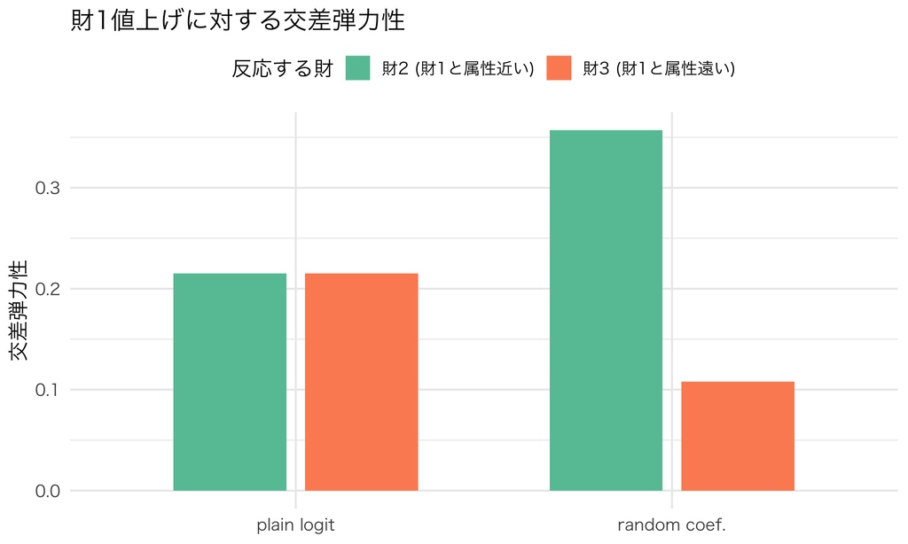

財1を値上げしたときの他財の反応。plain logit では財2・財3が同率、RC では属性の近い財2が強く反応する。

```r
df_plot <- data.frame(
  responder = rep(c("財2 (財1と属性近い)", "財3 (財1と属性遠い)"), 2),
  model     = rep(c("plain logit", "random coef."), each = 2),
  elasticity = c(E_homog[2, 1], E_homog[3, 1], E_heter[2, 1], E_heter[3, 1])
)
ggplot(df_plot, aes(model, elasticity, fill = responder)) +
  geom_col(position = position_dodge(width = 0.7), width = 0.6) +
  scale_fill_brewer(palette = "Set2") +
  labs(title = "財1値上げに対する交差弾力性",
       x = NULL, y = "交差弾力性", fill = "反応する財") +
  theme(legend.position = "top")
```

### 集計需要曲線の曲がり方も変わる

異質性は需要曲線の**形**にも影響する。価格への反応が人によって違うと、値上げしたときにまず価格に敏感な人が買わなくなり、価格をあまり気にしない人が買い続ける。そのため、集計した需要曲線の曲がり方も単純な logit とは変わってくる。財1の価格を動かして、需要曲線を描いてみよう。

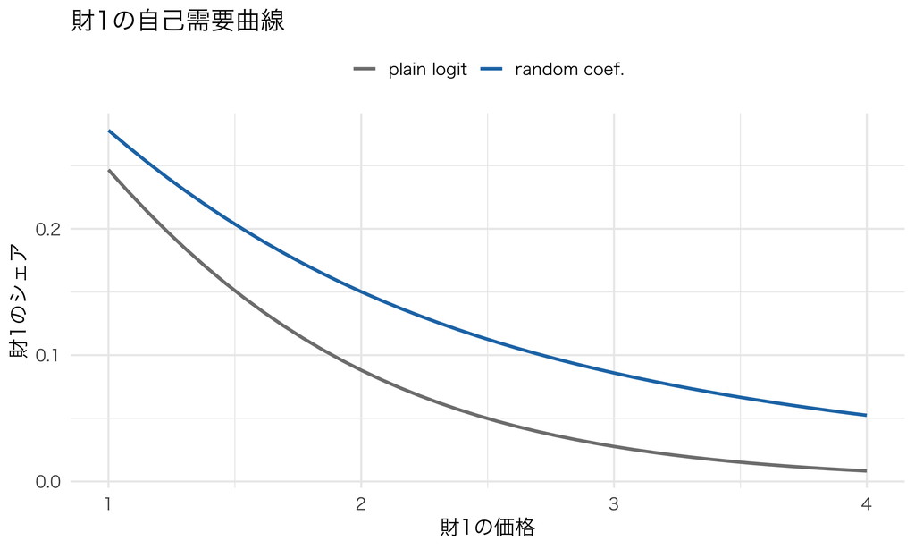

財1の自己需要曲線。異質性を入れると曲率が変わる。

```r
p_grid <- seq(1.0, 4.0, length.out = 40)
demand_curve <- function(sigma_x, sigma_p) {
  abar_use <- abar_for_sigma(sigma_p)
  sapply(p_grid, function(pp) {
    p_try <- p_base; p_try[1] <- pp
    sim_shares(x_char, p_try, beta0, beta_x, sigma_x, abar_use, sigma_p, nu_x, nu_p)[1]
  })
}
dc <- data.frame(
  price = rep(p_grid, 2),
  share = c(demand_curve(0.0, 0.0), demand_curve(1.2, 0.6)),
  model = rep(c("plain logit", "random coef."), each = length(p_grid))
)
ggplot(dc, aes(price, share, color = model)) +
  geom_line(linewidth = 1) +
  scale_color_manual(values = c("plain logit" = "grey50", "random coef." = "#1f77b4")) +
  labs(title = "財1の自己需要曲線", x = "財1の価格", y = "財1のシェア", color = NULL) +
  theme(legend.position = "top")
```

## 4. 識別の直感：$\sigma$ はどこから分かるのか

ここまでは異質性の大きさをこちらで決めていた。では、データから異質性パラメータ $\sigma$（好みのばらつき）を知るには、どのような情報が必要だろうか。主に次の3つを考える。

**(1) 価格変化への反応の「曲がり方」。** 均質な logit なら、価格を下げていくとシェアはロジスティック曲線に沿って増える。一方、価格感応度がばらついていると、価格に敏感な人とそうでない人とで反応する価格帯が違う。そのため、需要曲線の**曲率**が均質モデルとは変わる。価格の外生的変動、または妥当なIVで取り出した変動が十分にあれば、この違いが $\sigma$ の識別に役立つ。内生的な価格が単にばらついているだけでは、識別にはつながらない。

**(2) 市場間の選択集合・属性分布の変動。** ある市場では属性の近い財ばかり、別の市場では散らばっている、という変動は代替パターンの情報を増やす。ただし、それを「自然実験」と呼べるのは、品揃え・属性が未観測需要ショックに反応して選ばれていない等の外生性があるときだけである。そうでなければ操作変数や参入モデルが必要になる。

**(3) micro moments（個票・アンケート）。** 集計シェアだけだと $\sigma$ の識別は弱いことがある。そこで「購入者の平均所得」「2nd choice」等のモーメントをモデル予測と突き合わせる。所得と購入製品の関係は所得相互作用を、2nd choiceは局所的な代替関係を直接制約するため、関連する異質性パラメータの識別を大きく強めうる。ただし、どのmicro momentがどのパラメータを動かすかを対応づける必要がある。

**ヒント実証研究コーナー：Berry and Haile (2024) — micro dataによる識別条件**

**問い**：差別化財の需要は、どんな仮定のもとで（パラメトリックな関数形を置かずに）識別できるのか。

**データ・設定**：個票データ（消費者ごとの選択と、その人の属性）が使える状況を理論的に分析する。集計データを使う Berry-Levinsohn-Pakes (1995) の枠組みに対して、個票があると何が識別できるかを考える。

**識別戦略・結果**：同論文は、選択確率の構造、除外変数、support、completenessなどの条件を明示し、そのもとでmicro dataを使った差別化財需要のノンパラメトリック識別を示す。「個票とIVがあれば自動的に識別できる」という結果ではない。

**なぜこの回と繋がるか**：micro dataが、集計シェアだけでは得にくい識別情報を追加しうることを理論的に示す。ただし、この結果は正規・対数正規という分布仮定やrandom coefficient logitの仕様を正当化するものではない。実際の仕様の妥当性は、代替パターン、support、操作変数、仕様検定を別途確認する。

**ヒント実証研究コーナー：Petrin (2002) — ミニバン導入の便益を micro moments で測る**

**問い**：1984年のミニバン（Chrysler の Minivan）という新カテゴリーの登場は、消費者にどれだけの便益をもたらしたか。

**データ**：自動車の市場シェア・価格などの集計データに加えて、**購入世帯の属性データ**（Consumer Expenditure Survey などから、「どんな世帯がミニバンを買ったか」＝家族の人数など）を micro moment として併用した。

**識別戦略・モデル**：BLP型のrandom coefficient logitに、購入世帯の属性と車種特性の関係を表すmicro momentsを追加する。これにより、集計データだけでは弱かった人口属性と車種選好の関係に追加の識別情報が入り、代替パターンと厚生評価が変わる。

**主要な発見**：1984–1988年の累計で、補償変分（消費者便益）は約**28.05億ドル**、生産者利潤の変化を加えた総厚生変化は約**29.10億ドル**（1982–84年CPI調整ドル）と推定された。29億ドルは年額ではない。micro dataを入れないモデルは、より大きな厚生値を出すことも示される。

**なぜこの回と繋がるか**：micro moments を加えることで、異質性の推定や新製品の価値評価（消費者余剰の計算）がどう変わるかを示す例である。異質性の推定については、第9回でさらに詳しく扱う。

## 5. ミニBLPによる推定

ここからは、シェアデータを使って異質性パラメータ $\sigma$ を GMM で推定する。BLP (1995) の手続きをすべて実装すると計算が複雑になるため、基本的な流れを残した**ミニBLP**を作ってみよう。計算は次の3つの段階に分かれる。

- **内側（inner loop）**：$\sigma$ を固定し、シミュレーションシェアが観測シェアに一致するように平均効用 $\delta$ を解く。**縮小写像**を使う。
- **中間（linear step）**：得られた $\hat\delta_{jt}(\sigma)$ を $\delta = x'\beta - \bar\alpha^{\text{lvl}} p + \xi$ として **IV回帰**（第3回の 2SLS そのもの）にかけ、残差 $\hat\xi$ を得る。
- **外側（outer loop）**：GMM目的関数 $Q(\sigma) = \hat\xi'ZWZ'\hat\xi$ を $\sigma$ で最小化する。今回は1次元のグリッド上で目的関数を計算し、どこで最小になるかを確かめる。

### 5.1 DGP：観測データを作る

まず、データの生成過程を決める。財の数はJ=3、市場の数はT=60とする。価格は、限界費用に $\xi$ に反応するマークアップを加えて作るため、内生的になる。コストシフター $w$ は、後で操作変数を作るときに使う。

```r
# ---- 真のパラメータ ----
J <- 3; T <- 60; ns <- 200
beta0_true  <- 4.0      # 定数項
beta_x_true <- 1.5      # 属性 x への平均選好
abar_true   <- 0.5      # log価格係数の平均（中央値 = exp(0.5)）
sigma_true  <- 0.8      # 価格係数のばらつき（推定対象）

# ---- 製品属性・コストシフター・需要ショック ----
x  <- matrix(rnorm(T * J), T, J)                 # 属性（外生）
w  <- matrix(runif(T * J, 0.3, 1.3), T, J)       # コストシフター（需要から除外）
xi <- matrix(rnorm(T * J, 0, 0.6), T, J)         # 需要ショック（価格を内生化）

# 限界費用: mc = exp(g0 + gx*x + gw*w + omega)
g0 <- 0.2; gx <- 0.2; gw <- 1.0
omega <- matrix(rnorm(T * J, 0, 0.1), T, J)
mc <- exp(g0 + gx * x + gw * w + omega)

# 価格: 限界費用 + xi に反応するマークアップ（-> price と xi が相関 = 内生）
alpha_bar_true <- exp(abar_true + sigma_true^2 / 2)  # 水準での平均 E[alpha_i]
price <- mc * 1.4 + 0.8 * pmax(xi, 0) + 0.1

# シミュレーション個人（全市場で共通の nu を使う: 標準的な実装）
nu_p <- rnorm(ns)   # 価格係数の個人ショック
```

次に、シェアを計算する関数を定義する。後で縮小写像の計算に使うので、平均効用 $\delta$ を与えるとシェアを返す形にしておく。ここでは価格係数だけに異質性を入れる。$m(\bar\alpha,\sigma)=e^{\bar\alpha+\sigma^2/2}$ として、個人偏差を $\mu_{ij}=-(\alpha_i-m)p_j$ と中心化する。

```r
# delta_t: (J) 平均効用 = x'beta - alpha_bar*p + xi
# 戻り値: 集計インサイドシェア (J)
shares_from_delta <- function(delta_t, p_t, abar, sigma, nu_p) {
  alpha_i  <- exp(abar + sigma * nu_p)          # (ns)
  alpha_mean <- exp(abar + sigma^2 / 2)
  # mu[i,j] = -(alpha_i - E[alpha_i]) * p_j
  mu <- -outer(alpha_i - alpha_mean, p_t)         # (ns x J)
  V  <- sweep(mu, 2, delta_t, "+")               # delta を各列に足す
  eV <- exp(V)
  denom <- 1 + rowSums(eV)
  colMeans(eV / denom)
}

# ---- 観測シェアを真値で生成 ----
delta_true <- beta0_true + beta_x_true * x - alpha_bar_true * price + xi   # (T x J)
S_obs <- matrix(0, T, J)
for (t in 1:T) {
  S_obs[t, ] <- shares_from_delta(delta_true[t, ], price[t, ], abar_true, sigma_true, nu_p)
}
S0_obs <- 1 - rowSums(S_obs)   # outside share

cat("インサイドシェアの範囲:", round(range(S_obs), 4), "\n")
```

```
インサイドシェアの範囲: 0.0015 0.5432
```

```r
cat("アウトサイドシェアの範囲:", round(range(S0_obs), 4), "\n")
```

```
アウトサイドシェアの範囲: 0.3961 0.7048
```

```r
cat("価格とxiの相関（財ごと）:",
    round(sapply(1:J, function(j) cor(price[, j], xi[, j])), 3), "\n")
```

```
価格とxiの相関（財ごと）: 0.3 0.246 0.137
```

価格と $\xi$ に正の相関があることを確認しておこう。第3回と同じく、この内生性に対処するためにIVを使う。

**ノートこのミニBLPの価格係数は「中心値＋偏差」**

真のDGPでは、線形価格係数を $\alpha_{0,\mathrm{true}}=m(\bar\alpha,\sigma)$ に置く。そのため、$\alpha_{0,\mathrm{true}}+[\alpha_i-m]=\alpha_i$ となり、価格係数は厳密に対数正規である。

一方、候補となる $\sigma$ ごとに行う中間のIV回帰では、中心値 $\alpha_0$ を自由に推定する。探索中の係数は $\alpha_0+[\exp(\bar\alpha+\sigma\nu_i)-m(\bar\alpha,\sigma)]$ という**中心値＋中心化した対数正規偏差**になり、一般には純粋な対数正規ではない。これは、$\alpha_0$ を線形IVで profile out するための、講義用の簡略化である。すべての候補で純粋な対数正規族を保つには、$\bar\alpha$ と $\sigma$ をともに非線形パラメータとして外側で推定する。

### 5.2 内側：縮小写像で $\delta$ を解く

$\sigma$ を1つ固定したとき、シミュレーションシェアを観測シェアに一致させる $\delta$ を求めたい。そのために、次の更新を繰り返す。これがBLPの縮小写像（contraction mapping）である。

$$\delta^{\text{new}}_{jt} = \delta_{jt} + \ln S^{\text{obs}}_{jt} - \ln s_{jt}(\delta; \sigma).$$

予測シェアが観測シェアより小さければ $\delta$ を上げる、という更新になっている。縮小写像なので、初期値によらず一意の $\delta$ に収束する。ここでは、plain logit の Berry 反転 $\delta^{(0)} = \ln S^{\text{obs}} - \ln S^{\text{obs}}_0$ を初期値に使う。

```r
# sigma を固定して delta を解く（市場ごと）。trace_t で1市場の収束履歴を返す。
solve_delta <- function(sigma, abar, S_obs, S0_obs, price, nu_p,
                        tol = 1e-11, maxit = 1000, trace_t = NULL) {
  Tn <- nrow(S_obs); Jn <- ncol(S_obs)
  delta <- log(S_obs) - log(S0_obs)              # plain-logit 初期値 (T x J)
  trace <- NULL
  for (t in 1:Tn) {
    d <- delta[t, ]
    errs <- numeric(0)
    for (it in 1:maxit) {
      s_pred <- shares_from_delta(d, price[t, ], abar, sigma, nu_p)
      d_new  <- d + log(S_obs[t, ]) - log(s_pred)
      err    <- max(abs(d_new - d))
      errs   <- c(errs, err)
      d <- d_new
      if (err < tol) break
    }
    delta[t, ] <- d
    if (!is.null(trace_t) && t == trace_t) trace <- errs
  }
  list(delta = delta, trace = trace)
}

# 真の sigma で解いて、観測シェアを再現できるか確認
res_true <- solve_delta(sigma_true, abar_true, S_obs, S0_obs, price, nu_p, trace_t = 1)
recon_err <- max(abs(sapply(1:T, function(t)
  shares_from_delta(res_true$delta[t, ], price[t, ], abar_true, sigma_true, nu_p) - S_obs[t, ])))
cat("シェア再現の最大誤差:", recon_err, "\n")
```

```
シェア再現の最大誤差: 0.000000000004128475
```

```r
cat("delta 回収の最大誤差（真値との差）:", max(abs(res_true$delta - delta_true)), "\n")
```

```
delta 回収の最大誤差（真値との差）: 0.00000000008480638
```

```r
cat("市場1が収束するまでの反復回数:", length(res_true$trace), "\n")
```

```
市場1が収束するまでの反復回数: 76
```

縮小写像の収束の様子を、反復ごとの誤差の対数でプロットする。直線的に（幾何級数的に）誤差が落ちていくのが縮小写像の特徴だ。

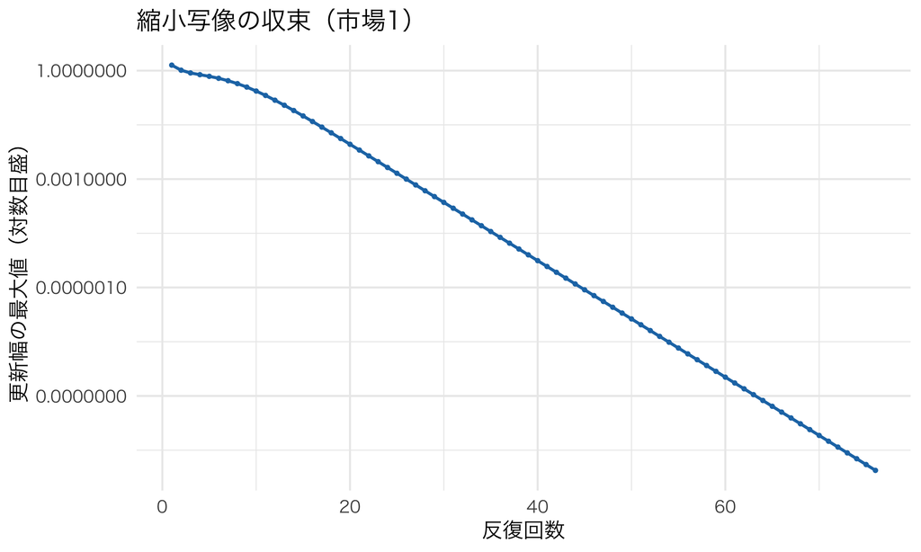

BLP 縮小写像の収束。誤差が対数目盛でほぼ直線に落ちる = 幾何収束。

```r
df_trace <- data.frame(iter = seq_along(res_true$trace), err = res_true$trace)
ggplot(df_trace, aes(iter, err)) +
  geom_line(color = "#1f77b4", linewidth = 0.9) +
  geom_point(color = "#1f77b4", size = 0.8) +
  scale_y_log10(labels = label_number()) +
  labs(title = "縮小写像の収束（市場1）",
       x = "反復回数", y = "更新幅の最大値（対数目盛）")
```

### 5.3 中間：IV回帰で $\xi$ を取り出す

$\hat\delta_{jt}(\sigma)$ が求まったら、線形式 $\delta = \beta_0 + \beta_x x - \alpha_0 p + \xi$ の回帰を行う。価格は内生的なので、操作変数 $Z$ を使った2SLS（GMM）で推定する。

この講義用のDGPでは、$Z$ に定数・$x$・自財のコストシフター $w$・他製品の属性和／コスト和を入れる。標準的なBLP IVは、企業IDを使って「同じ企業の他製品」と「他企業の製品」の属性和を分けるが、ここでは企業IDを省いて簡略化している。操作変数が妥当であるためには、これらが自財の $\xi$ と無相関であるという除外制約が必要になる。

```r
# 操作変数 Z: 定数, x, w, ライバルのx和, ライバルのw和
build_Z <- function(x, w) {
  Tn <- nrow(x); Jn <- ncol(x)
  Z <- matrix(0, Tn * Jn, 5)
  row <- 1
  for (t in 1:Tn) for (j in 1:Jn) {
    others <- setdiff(1:Jn, j)
    Z[row, ] <- c(1, x[t, j], w[t, j], sum(x[t, others]), sum(w[t, others]))
    row <- row + 1
  }
  Z
}
# 説明変数 X: 定数, x, price（price が内生）
build_X <- function(x, price) {
  cbind(1, as.vector(t(x)), as.vector(t(price)))
}

Z <- build_Z(x, w)
Xmat <- build_X(x, price)

# GMM 目的関数（重み行列 W = (Z'Z)^{-1}）
gmm_step <- function(sigma, abar) {
  res <- solve_delta(sigma, abar, S_obs, S0_obs, price, nu_p)
  d <- as.vector(t(res$delta))                   # (T*J) を製品×市場の順に並べる
  W <- solve(crossprod(Z))                        # (Z'Z)^{-1}
  ZX <- crossprod(Z, Xmat)                        # Z'X
  Zd <- crossprod(Z, d)                           # Z'delta
  theta1 <- solve(t(ZX) %*% W %*% ZX, t(ZX) %*% W %*% Zd)  # IV-GMM 線形パラメータ
  xi_hat <- d - Xmat %*% theta1
  g <- crossprod(Z, xi_hat)                        # モーメント Z'xi
  Q <- as.numeric(t(g) %*% W %*% g)
  list(Q = Q, theta1 = as.vector(theta1), xi_hat = xi_hat)
}
```

**警告X と delta の並べ方に注意**

`solve_delta` は $\delta$ を `T x J` の行列で返す。IV回帰ではこれを1本のベクトルに並べ直すが、その順序を `build_X` の順序と**一致させる**必要がある。ここでは両方とも、市場 t を固定して財 j を順に並べている。行列を転置してから `as.vector` を使うと、この順序になる。並び方がずれると、$\delta$ と $x$・$p$ が別の製品や市場に対応してしまうので注意しよう。

### 5.4 外側：GMM目的関数を $\sigma$ のグリッドで見る

$\sigma$ を動かして $Q(\sigma)$ を計算し、真値の近くで最小になるかを確かめよう。実務では最適化アルゴリズム（例えば Nelder-Mead）を使うが、ここでは目的関数の形が分かるように、1次元のグリッド上で計算する。今回は $\bar\alpha$ を真値に固定し、$\sigma$ の識別を確かめる。同時に推定する場合も、基本的な考え方は同じである。

```r
sigma_grid <- c(0.0, 0.2, 0.4, 0.6, 0.8, 1.0, 1.2, 1.4)
Q_vals <- sapply(sigma_grid, function(s) gmm_step(s, abar_true)$Q)

df_Q <- data.frame(sigma = sigma_grid, Q = Q_vals)
kable(df_Q, digits = 4, caption = "GMM目的関数 Q(sigma)")
```

GMM目的関数 Q(sigma)

| sigma | Q |
| --- | --- |
| 0.0 | 22.0778 |
| 0.2 | 15.9630 |
| 0.4 | 8.2148 |
| 0.6 | 3.2470 |
| 0.8 | 1.1034 |
| 1.0 | 1.1735 |
| 1.2 | 2.8089 |
| 1.4 | 5.4584 |

```r
cat("グリッド上の argmin:", sigma_grid[which.min(Q_vals)], " （真値 = 0.8）\n")
```

```
グリッド上の argmin: 0.8  （真値 = 0.8）
```

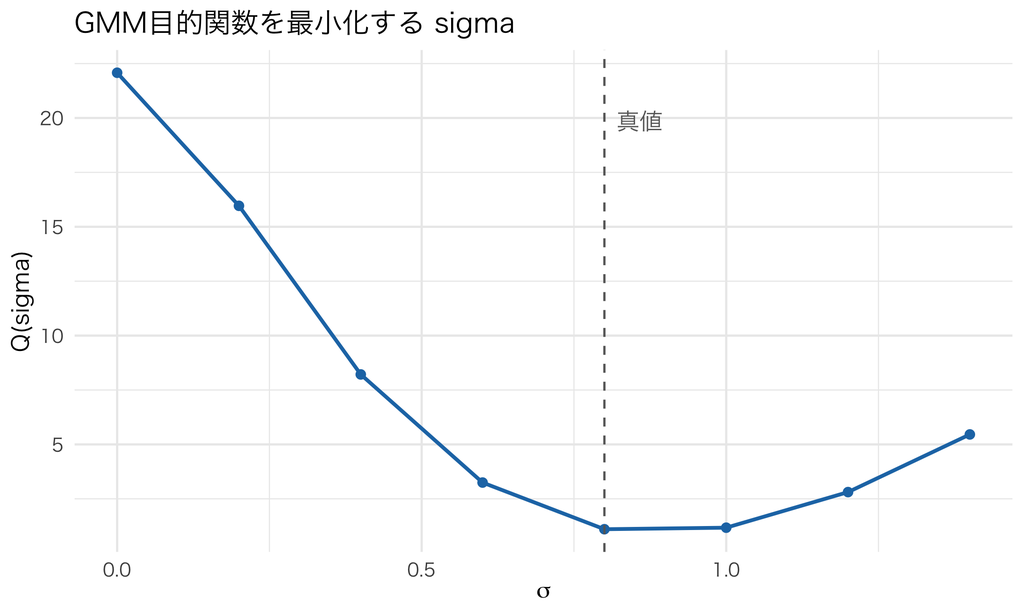

GMM目的関数 Q(sigma)。真値 0.8 の近くで谷になる。

```r
ggplot(df_Q, aes(sigma, Q)) +
  geom_line(color = "#1f77b4", linewidth = 1) +
  geom_point(size = 2, color = "#1f77b4") +
  geom_vline(xintercept = sigma_true, linetype = "dashed", color = "grey40") +
  annotate("text", x = sigma_true + 0.02, y = max(Q_vals) * 0.9,
           label = "真値", hjust = 0, color = "grey40") +
  labs(title = "GMM目的関数を最小化する sigma",
       x = expression(sigma), y = "Q(sigma)")
```

真値 $\sigma=0.8$ の近くで $Q$ が最小になり、異質性の大きさを推定できた。この $\sigma$ に対応する線形パラメータ（定数・$\beta_x$・平均価格係数の負値 $-\alpha_0$）も、真値に近いか確認しよう。

```r
best_sigma <- sigma_grid[which.min(Q_vals)]
fit_best <- gmm_step(best_sigma, abar_true)
data.frame(
  parameter = c("定数(beta0)", "beta_x", "-alpha_bar(価格)"),
  estimated = round(fit_best$theta1, 3),
  truth     = round(c(beta0_true, beta_x_true, -alpha_bar_true), 3)
) |> kable(caption = "回収された線形パラメータ vs 真値")
```

回収された線形パラメータ vs 真値

| parameter | estimated | truth |
| --- | --- | --- |
| 定数(beta0) | 3.828 | 4.00 |
| beta_x | 1.432 | 1.50 |
| -alpha_bar(価格) | -2.217 | -2.27 |

**重要ミニBLPの計算手順を振り返る**

- **内側**：$\sigma$ を固定 → 縮小写像で $\delta$ を解く（シェアを完全一致させる）。
- **中間**：$\hat\delta$ を IV回帰 → 価格の内生性を除去して $\hat\xi$ を得る。
- **外側**：$\hat\xi$ が操作変数と無相関になるよう $\sigma$ を選ぶ（GMM）。

実務では、こうした計算にPythonの `pyblp` が使われる。今回の3つの段階を理解しておくと、計算がうまく進まないときにも、内側の反復が収束しているか、操作変数に問題がないか、といった点を考えやすくなる。

**ヒント実証研究コーナー：Berry, Levinsohn and Pakes (1995) — シェアデータだけからマークアップまで**

**問い**：新車の市場シェアと価格・スペックのデータだけから、消費者の需要（価格弾力性・代替性）と、メーカーのマークアップ（価格と限界費用の差）を同時に推定できるか。

**データ**：1971–1990年の米国自動車市場を対象とする。車種ごとの販売台数から求めたシェア、価格、馬力・燃費・サイズなどのスペックを使う。**個票は使わず、集計データのみ**を用いる。

**識別戦略・モデル**：今回のミニBLPのもとになった手法である。random coefficient logit の需要に供給側のBertrand-Nash均衡を組み合わせ、縮小写像とGMMを使って推定する。需要側の標準的なBLP instrumentsは、自財の外生属性に加え、同一企業の他車種と他企業の車種の属性和を別々に用いる。

**主要な発見**：集計データから、車種ごとの限界費用とマークアップを推定した。例えば、高級車ほどマークアップ率が高いという結果が得られている。コストを直接観測しなくても、需要と均衡条件からこうした違いを推定できる。マークアップ率は、おおむね**2〜3割**の範囲に推定された車種が多い。

**なぜこの回と繋がるか**：この論文は、今回の講義と実証IOの基礎にある。シェア・価格・属性・企業所有のデータに需要と供給の仮定を組み合わせて、直接は観測できない限界費用を復元する。次に行う合併分析でも、この枠組みを使う。

## 6. 合併分析：供給側を加える

ここまでは需要を推定してきた。次に、**供給側**、つまり企業の価格設定行動を加えてみよう。需要と供給の両方を使うと、2社が合併したときに価格がどれだけ上がるかを計算できる。この計算が合併分析（merger analysis）である。

### 6.1 Bertrand-Nash 均衡と限界費用の逆算

各企業は、自社が持つ製品群の利潤を最大化するように価格を設定する（Bertrand 競争）。1製品1企業のとき、企業 $j$ の一階条件（FOC）は

$$s_j + (p_j - mc_j)\frac{\partial s_j}{\partial p_j} = 0.$$

多製品企業なら、自社の**他製品への波及**も考える。ここで所有関係を表す行列を導入する。$\Omega$ を「製品 $j$ と $k$ が同じ企業なら1、違えば0」とすると、FOC はまとめて

$$s - \Delta\,(p - mc) = 0, \qquad \Delta_{jk} = -\Omega_{jk}\frac{\partial s_k}{\partial p_j},$$

したがって

$$p = mc + \Delta^{-1} s.$$

第2項 $\Delta^{-1}s$ が**マークアップ**にあたる。価格 $p$ とシェア $s$ は観測でき、需要の微分（$\partial s/\partial p$）は推定した需要から計算できる。したがって、**上の式を逆に解けば、限界費用 $mc$ を復元できる**。コストのデータがなくても、企業の価格設定について仮定を置くことで、限界費用を求められるのである。

**ノート導出：所有行列とマークアップ項**

企業 $f$ が製品集合 $\mathcal{F}_f$ を持つとき、利潤は $\pi_f = \sum_{k\in\mathcal{F}_f}(p_k - mc_k)s_k$。$p_j$（$j\in\mathcal{F}_f$）で微分してゼロと置くと

$$s_j + \sum_{k\in\mathcal{F}_f}(p_k - mc_k)\frac{\partial s_k}{\partial p_j} = 0.$$

所有ダミー $\Omega_{jk}=\mathbf{1}[j,k \text{ 同一企業}]$ を使えば、和の範囲を全製品に広げた上で、$\Omega$ によって自社製品だけを残せる。行列 $\Delta$ を $\Delta_{jk} = -\Omega_{jk}\,\partial s_k/\partial p_j$ と定義すると、上式は $s = \Delta(p - mc)$ と書ける。これを価格について解けば、$p = mc + \Delta^{-1}s$ が得られる。合併後は同じ企業になる製品が増えるので、この $\Omega$ の該当部分を0から1に変える。

需要の微分（mixed logit）は、個人シェア $s_{ij}$ を使って
$$\frac{\partial s_k}{\partial p_j} = \begin{cases}
\text{mean}_i\big[-\alpha_i\, s_{ij}(1 - s_{ij})\big] & k = j,\\[4pt]
\text{mean}_i\big[\alpha_i\, s_{ik}\, s_{ij}\big] & k \neq j.
\end{cases}$$
価格は $-\alpha_i p$ として効用に入るので、微分の符号に注意しよう。個人ごとに計算した値を平均することで、ここでも積分をモンテカルロ法で近似している。

### 6.2 手順を1市場で実装する

推定した需要を使って、4財の市場で財1と財2の合併を分析しよう。まず、観測価格とFOCから $mc$ を逆算する。次に所有行列を合併後のものに変え、固定点反復 $p^{\text{new}} = mc + \Delta(p)^{-1}s(p)$ によって新しい均衡価格を求める。

```r
# --- 合併分析用の需要（推定済みパラメータを使う想定）---
# 4財市場。価格係数は対数正規（推定した abar, sigma を流用）。
abar_m  <- 0.5      # 推定された log価格係数の平均
sigma_m <- 0.8      # 推定された異質性
Jm <- 4
nu_m <- rnorm(ns)   # この市場のシミュレーション個人

# 製品の平均効用（価格を除く部分 = x'beta + xi）と真の限界費用
# （分析者は mc を知らない。FOC から逆算するのが仕事）
xbeta_xi <- c(3.0, 2.6, 2.9, 2.7)         # 財1-4 の x'beta + xi
mc_true_m <- c(1.0, 1.1, 1.2, 0.9)        # 真の限界費用（後で答え合わせに使うだけ）

# 個人選択確率 (ns x Jm) を価格 p から計算
choice_probs <- function(p) {
  alpha_i <- exp(abar_m + sigma_m * nu_m)          # (ns)
  V <- sweep(-outer(alpha_i, p), 2, xbeta_xi, "+") # v[i,j] = xbeta_xi_j - alpha_i p_j
  eV <- exp(V)
  eV / (1 + rowSums(eV))                            # outside = 1
}
agg_shares <- function(p) colMeans(choice_probs(p))

# シェアの価格微分 (Jm x Jm), 要素[k,j] = ds_k/dp_j
dS_dp <- function(p) {
  alpha_i <- exp(abar_m + sigma_m * nu_m)
  sij <- choice_probs(p)                            # (ns x Jm)
  Jmat <- matrix(0, Jm, Jm)
  for (j in 1:Jm) for (k in 1:Jm) {
    if (k == j) {
      Jmat[k, j] <- mean(-alpha_i * sij[, j] * (1 - sij[, j]))
    } else {
      Jmat[k, j] <- mean(alpha_i * sij[, k] * sij[, j])
    }
  }
  Jmat
}

# 所有行列 Omega（groups が同じ = 同一企業）
owner_matrix <- function(groups) outer(groups, groups, FUN = function(a, b) as.numeric(a == b))

# FOC の Delta と s（Delta[j,k] = -Omega[j,k] * ds_k/dp_j）
# dS_dp は [k,j]=ds_k/dp_j を返すので、転置して [j,k]=ds_k/dp_j にする
markup_pieces <- function(p, groups) {
  Jmat <- dS_dp(p)
  Omega <- owner_matrix(groups)
  Delta <- -(Omega * t(Jmat))       # [j,k] = -Omega[j,k]*ds_k/dp_j
  list(Delta = Delta, s = agg_shares(p))
}

# 均衡を固定点反復で解く: p = mc + Delta(p)^{-1} s(p)
solve_equilibrium <- function(mc, groups, p_init, tol = 1e-11, maxit = 2000) {
  p <- p_init
  for (it in 1:maxit) {
    mp <- markup_pieces(p, groups)
    p_new <- mc + solve(mp$Delta, mp$s)
    err <- max(abs(p_new - p))
    p <- p_new
    if (err < tol) return(list(p = p, iters = it, ok = TRUE))
  }
  list(p = p, iters = maxit, ok = FALSE)
}
```

まず合併前（4社が各1製品）の均衡を求め、そこから $mc$ を逆算する。逆算した $mc$ が「真の $mc$」と一致すれば、FOC の実装が正しいことの確認になる。

```r
groups_pre <- c(1, 2, 3, 4)   # 合併前：4社バラバラ

# 合併前均衡を前向きに計算（内部整合的なデータを作るため）
eq_pre <- solve_equilibrium(mc_true_m, groups_pre, p_init = mc_true_m * 1.5)
p0 <- eq_pre$p
s0 <- agg_shares(p0)
cat("合併前均衡の収束:", eq_pre$ok, " 反復:", eq_pre$iters, "\n")
```

```
合併前均衡の収束: TRUE  反復: 18
```

```r
cat("合併前価格 p0:", round(p0, 3), "\n")
```

```
合併前価格 p0: 2.1 2.113 2.296 1.91
```

```r
cat("合併前シェア s0:", round(s0, 3), " outside:", round(1 - sum(s0), 3), "\n")
```

```
合併前シェア s0: 0.169 0.111 0.123 0.157  outside: 0.44
```

```r
# 観測価格 p0 から FOC で mc を逆算（分析者の仕事）
mp0 <- markup_pieces(p0, groups_pre)
mc_implied <- p0 - solve(mp0$Delta, mp0$s)
cat("\n逆算した mc:", round(mc_implied, 4), "\n")
```

```
逆算した mc: 1 1.1 1.2 0.9
```

```r
cat("真の mc    :", round(mc_true_m, 4), "\n")
```

```
真の mc    : 1 1.1 1.2 0.9
```

```r
cat("逆算の最大誤差:", max(abs(mc_implied - mc_true_m)), "\n")
```

```
逆算の最大誤差: 0.000000000001512457
```

逆算した限界費用が真値と一致することを確認できた。次に、財1と財2を同じ企業が所有するように所有行列を変え、合併後の均衡を求める。

```r
groups_post <- c(1, 1, 3, 4)   # 財1・財2が合併して同一企業に

eq_post <- solve_equilibrium(mc_implied, groups_post, p_init = p0)
p1 <- eq_post$p
s1 <- agg_shares(p1)

cat("合併後均衡の収束:", eq_post$ok, " 反復:", eq_post$iters, "\n")
```

```
合併後均衡の収束: TRUE  反復: 24
```

```r
merger_tbl <- data.frame(
  product   = paste0("財", 1:4),
  merging   = c("○", "○", "", ""),
  price_pre  = round(p0, 3),
  price_post = round(p1, 3),
  pct_change = round((p1 - p0) / p0 * 100, 2),
  share_pre  = round(s0, 3),
  share_post = round(s1, 3)
)
kable(merger_tbl, caption = "合併の効果（財1・財2の合併）")
```

合併の効果（財1・財2の合併）

| product | merging | price_pre | price_post | pct_change | share_pre | share_post |
| --- | --- | --- | --- | --- | --- | --- |
| 財1 | ○ | 2.100 | 2.327 | 10.79 | 0.169 | 0.147 |
| 財2 | ○ | 2.113 | 2.485 | 17.64 | 0.111 | 0.083 |
| 財3 |  | 2.296 | 2.315 | 0.84 | 0.123 | 0.134 |
| 財4 |  | 1.910 | 1.941 | 1.66 | 0.157 | 0.169 |

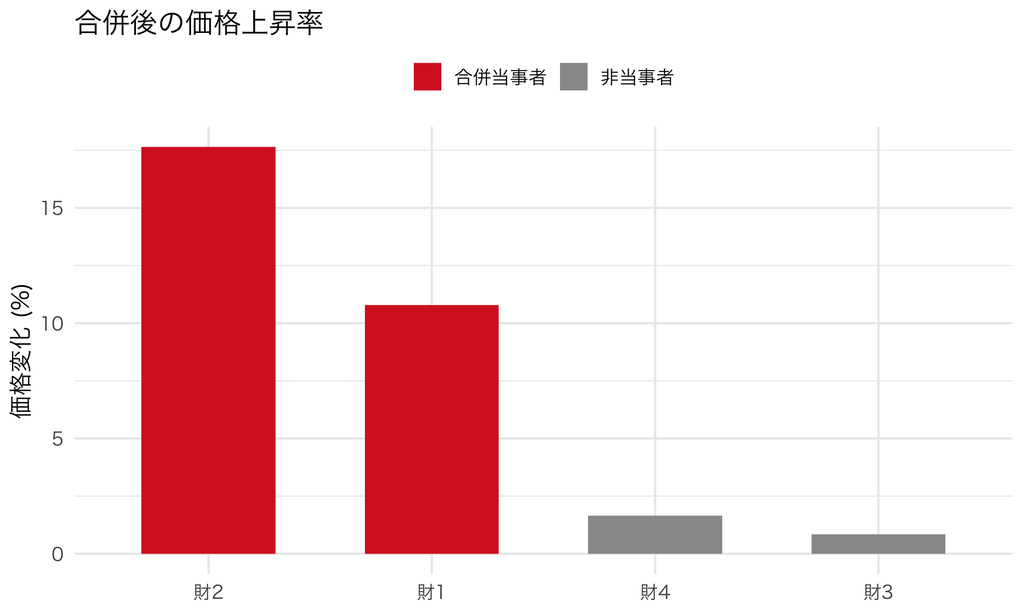

合併による価格変化。合併した財1・財2が大きく上昇、非合併財はわずかに上昇。

```r
df_m <- data.frame(product = paste0("財", 1:4),
                   pct = (p1 - p0) / p0 * 100,
                   merging = c("合併当事者", "合併当事者", "非当事者", "非当事者"))
ggplot(df_m, aes(reorder(product, -pct), pct, fill = merging)) +
  geom_col(width = 0.6) +
  scale_fill_manual(values = c("合併当事者" = "#d62728", "非当事者" = "grey60")) +
  labs(title = "合併後の価格上昇率", x = NULL, y = "価格変化 (%)", fill = NULL) +
  theme(legend.position = "top")
```

合併した財1・財2の価格は大きく上がる一方、非当事者の財3・財4の上昇は小さい。これが**単独効果（unilateral effect）**である。合併後に財1を値上げすると、離れた客の一部は、同じ企業が持つ財2へ移る。財2に移った客からも自社が利益を得られるため、合併前より値上げをしやすくなる。

### 6.3 diversion ratio と UPP、消費者余剰

合併審査でよく使われる簡便な指標も計算してみよう。**diversion ratio** $D_{j\to k}$ は、財 $j$ の値上げによって離れた客のうち、財 $k$ へ移る割合を表す。

$$D_{j\to k} = -\frac{\partial s_k/\partial p_j}{\partial s_j/\partial p_j}.$$

この割合が大きいほど、2財は近い代替関係にあり、合併による弊害も大きくなる。もう1つの指標である **UPP（upward pricing pressure）** は、均衡価格をすべて計算せずに値上げ圧力を測るために使う。財1については次の式で表される。ここでは、効率化 $E$ を無視した簡便版を計算する。

$$\text{UPP}_1 = D_{1\to 2}\,(p_2 - mc_2) - E\cdot mc_1.$$

```r
Jmat0 <- dS_dp(p0)
diversion <- function(j, k) -Jmat0[k, j] / Jmat0[j, j]

cat("diversion D(財1->財2):", round(diversion(1, 2), 3), "\n")
```

```
diversion D(財1->財2): 0.178
```

```r
cat("diversion D(財2->財1):", round(diversion(2, 1), 3), "\n")
```

```
diversion D(財2->財1): 0.247
```

```r
# UPP（財1、効率化ゼロ）: D_{1->2} * (p2 - mc2)
upp1 <- diversion(1, 2) * (p0[2] - mc_implied[2])
cat("\nUPP(財1, 効率化なし):", round(upp1, 4),
    " （合併前価格の", round(upp1 / p0[1] * 100, 1), "%）\n")
```

```
UPP(財1, 効率化なし): 0.18  （合併前価格の 8.6 %）
```

消費者余剰の変化は、logit の **logsum（inclusive value）公式**で測る。各消費者の期待効用は $\ln(1 + \sum_j e^{v_{ij}})$ に比例し、これを価格の単位に直すため $1/\alpha_i$ で割って集計する。

```r
cs_logsum <- function(p) {
  alpha_i <- exp(abar_m + sigma_m * nu_m)
  V <- sweep(-outer(alpha_i, p), 2, xbeta_xi, "+")
  inclusive <- log(1 + rowSums(exp(V)))    # outside 込み（効用0 -> exp(0)=1）
  mean(inclusive / alpha_i)                 # 各自の alpha で割って平均
}
cs0 <- cs_logsum(p0); cs1 <- cs_logsum(p1)
cat("消費者余剰（1人あたり）: 合併前", round(cs0, 4),
    " 合併後", round(cs1, 4), " 変化", round(cs1 - cs0, 4), "\n")
```

```
消費者余剰（1人あたり）: 合併前 1.969  合併後 1.8897  変化 -0.0793
```

この例では、合併による値上げで消費者余剰が減少している。合併審査では、こうした消費者への不利益が問題になる。

**ノートビジネスの現場で：価格改定シミュレータの中身**

小売やメーカーの価格改定シミュレータにも、ここで学んだ需要推定と価格設定のモデルが使われる。例えば、主力商品を5%値上げしたら、自社の他商品も含めて数量・売上・利益がどう動くかを、推定した需要と Bertrand の FOC から計算する。数学的な枠組みは合併分析と同じである。所有行列を「自社製品だけ1」にして、価格を外生的に変えた反実仮想を計算する。今回の計算は、実務で使うシミュレータやダッシュボードにもつながっている。

**ヒント実証研究コーナー：Nevo (2001) — 高マージンは共謀か、ブランド力か**

**問い**：朝食シリアル業界は、価格が限界費用よりずっと高い（高マージン）。これは企業が裏で協調（共謀）しているからか、それとも製品差別化とブランド力の結果か。

**データ**：米国の朝食シリアル市場について、都市×四半期のスキャンパネル（POS）データを使う。ブランドごとの価格・シェア・製品特性が記録されている。

**識別戦略・モデル**：random coefficient logitで需要を推定し、供給側の行動仮説（単独最大化 vs 協調）のもとでマークアップを比べた。ブランド固定効果などで平均品質を制御するだけでなく、価格の内生性には他都市の同一ブランド平均価格（Hausman型IV）や流通費用のproxyなど複数のIVを用い、その仮定と頑健性を検討している。

**主要な発見**：観測される高マージンは、**共謀を仮定しなくても**、製品差別化とブランド力（強い選好）で説明できるという結果を得た。price-cost マージンはおおむね**4〜5割**と推定されたが、これは単独価格設定と矛盾しなかった。

**なぜこの回と繋がるか**：需要推定（random coefficient logit）と供給側モデル（Bertrand-Nash）を組み合わせて、観測できない限界費用や企業の行動を分析する例である。合併審査でも、現在の競争がどれくらい激しいかを調べるために、同じ枠組みを使う。

**ヒント実証研究コーナー：Miller and Weinberg (2017) — 合併後に協調的値上げは起きたか**

**問い**：2008年の MillerCoors 合弁（Miller と Coors のビール事業統合）の後、ビール業界で価格が上がったか。上がったとすれば、それは単独効果か、それとも残った大手（Anheuser-Busch と MillerCoors）の**協調的**な値上げか。

**データ**：合弁前後の米国ビール市場のスキャンデータを使う。ブランド×地域×時点の価格・シェアが記録されている。

**識別戦略・モデル**：random coefficient logit で需要を推定し、合弁前のデータで供給側モデルを較正する。その上で、単独 Nash による合弁後の価格予測を、実際の価格と比べる。実際の値上げが単独効果の予測を上回る分を、協調の強まりと解釈した。

**主要な発見**：合弁後、単独 Nash が予測する以上の価格上昇が観測され、**協調的価格上昇（部分的協調）**の証拠と解釈された。とくに Miller と Coors の主要ブランドで、合弁後に価格が数%上昇した。

**なぜこの回と繋がるか**：今回の合併シミュレーションで計算した単独効果は、合併後の結果を検証する際の比較基準にもなる。予測と実際の価格の差を調べることで、単独効果だけでは説明できない協調の可能性を検討する。第5回の合併審査の実務にも関わる分析である。

**ヒント実証研究コーナー：Adam, He and Zheng (2023, Management Science) — ロングテール市場の需要推定と機械学習**

**問い**：オンライン小売のように「売れる商品はごく一部、大半は販売数ゼロか極少（ロングテール）」という市場では、従来の random coefficient logit（BLP）はうまく推定できるか。

**データ・設定**：多数の商品を扱うオンラインマーケットプレイスで、販売数が0の商品が大量にある状況を分析する。BLPは販売数が正の商品しか扱えず、ゼロ販売をどう扱うかによってセレクションバイアスが生じる。

**識別戦略・モデル**：2段階推定を提案する。第1段階で、**random coefficient logit のデータ生成過程を模した構造を持つニューラルネットワーク（深層学習）**で全商品の市場シェアを予測する。第2段階で、その予測を使って観測シェアを再重み付けし、セレクションバイアスを補正しつつ構造モデルの因果的解釈を保つ。市場数について推定量の一致性を示した。

**主要な発見**：ロングテールのシミュレーションデータと実データの両方で、素朴なBLPより正確に消費者行動を推定できた。得られた推定値は、価格設定や品揃え（assortment）の意思決定に使える。

**なぜこの回と繋がるか**：この論文では、今回学んだBLPの枠組みに機械学習を組み合わせ、ECに多い、販売数がゼロまたは少数の商品に対応する。第7回以降で扱う機械学習の方法が、需要推定にも使われている例である。

## まとめ

**重要この回のポイント**

- **属性への係数を消費者ごとに変える**ことで、評価の異質性を表した（$\beta_i = \beta + \Sigma^{1/2}\nu_i$、価格係数は対数正規で正に保つ）。共通係数の logit にも $\varepsilon_{ij}$ による選択の違いはあったが、今回はその違いを属性に結びつけた。係数を固定すれば logit になり、その選択確率を人々について積分して市場シェアを求める。
- 今回のDGPでは、属性への好みの違いを入れることで、ネストを指定しなくても**属性の近い財どうしが代替しやすい**という関係が表れ、集計レベルのIIAが破れた。ただし、どのrandom coefficientでも同じ近接性が表れるわけではない。
- **ミニBLPの推定は3つの段階に分かれる**。内側の縮小写像で $\delta$ を求め、中間のIV回帰で $\xi$ を取り出し、外側のGMMで $\sigma$ を選ぶ。シミュレーションでは真値 $\sigma=0.8$ に近い値を推定できた。
- **識別**には、価格反応の曲がり方、市場間の変動、**micro moments**（購入者の所得、2nd choice）の情報を使う。Berry-Haileが示すように、micro dataがあっても、構造・support・completeness等の条件を明示する必要がある。
- 供給側（Bertrand-Nash、$p = mc + \Delta^{-1}s$）を加えると、推定した需要から**合併後の価格上昇**を計算できる。今回の例では、合併当事者の価格が上がる単独効果を確認した。diversion ratio・UPPは、その影響を調べるための簡便な指標である。
- 垂直的差別化も水平的差別化も、消費者の選択を集計して需要を作れる。同じ現在のシェアでも好みの構造が違えば値上げ後の需要は異なるので、属性への評価の異質性を捉えることが、代替パターンや合併効果の予測に重要になる。

## 宿題

- ブラウザ実験室（playground4.html）で、今回のシミュレーションの数値を自分でいじって遊んでみよう。インストール不要、ブラウザだけでRが動く（初回ロードのみ30秒〜1分かかる）。
1. **pyblp のドキュメントを眺めてみよう**。https://pyblp.readthedocs.io/ のチュートリアルを開き、「problem」「integration」「optimization」という言葉が、今回の計算の構造（外側・内側・積分）のどこに対応するかを考えてみよう。コードを動かす必要はなく、計算の流れを追えればよい。
2. 本文の交差弾力性のコードで、財1と財2の属性 `x_char` を「近い」から「遠い」に変えて（例：`c(1.0, -0.9, -0.8)`）実行し直そう。財1↔︎財2の交差弾力性がどう変わるかを見て、属性への好みの違いが代替関係にどう影響するかを確かめよう。
3. 合併分析のコードで、`groups_post` を `c(1, 1, 1, 4)`（財1・2・3が3社合併）に変えてみよう。当事者が増えると価格上昇率はどう変わるだろうか。
4. ChatGPT に「BLP の contraction mapping はなぜ縮小写像になるのか、直感的に説明して」と聞き、本文の説明と比べてみよう。
5. coding課題は `assignment4.qmd` を参照。J=3・T=60のDGPを自作し、$\sigma$ のグリッド上でGMMを計算した上で、財1・2の合併を分析する。今回の手順を一通り自分で実装するので、少し時間のかかる課題である。

## 次回予告

第5回は、公正取引委員会の方をお招きする**ゲスト講義**である。今回計算した diversion ratio・UPP・単独効果・消費者余剰の変化が、実際の企業結合審査でどう使われるのかを伺う。企業や経済コンサルが提出する分析を、当局はどのように評価し、どこを争点とするのか。今回のミニBLPと合併シミュレーションを思い出しながら、**合併審査の実務**とのつながりを考えてみよう。

その後の第6回では、需要データを**実験的に作る**コンジョイント分析を扱う。今回は市場で観測されたデータから選好を推定したが、コンジョイントでは、選好を測るためにデータそのものを設計する。

## 参考文献

- Bresnahan, T. F. (1987). “Competition and Collusion in the American Automobile Industry: The 1955 Price War.” *The Journal of Industrial Economics*, 35(4), 457–482. [論文](https://doi.org/10.2307/2098583)
- Train, K. E. (2009). *Discrete Choice Methods with Simulation*, 2nd ed., Cambridge University Press, Chapters 3 and 6. [Chapter 6](https://eml.berkeley.edu/books/choice2nd/Ch06_p134-150.pdf)
- 上武康亮・遠山祐太・若森直樹・渡辺安虎『実証ビジネス・エコノミクス』日本評論社（第4章）。
- Nevo, A. (2000). “A Practitioner’s Guide to Estimation of Random-Coefficients Logit Models of Demand.” *Journal of Economics & Management Strategy*, 9(4), 513–548.
- Nevo, A. (2001). “Measuring Market Power in the Ready-to-Eat Cereal Industry.” *Econometrica*, 69(2), 307–342.
- Berry, S., Levinsohn, J., and Pakes, A. (1995). “Automobile Prices in Market Equilibrium.” *Econometrica*, 63(4), 841–890.
- Werden, G. J., and Froeb, L. M. (1994). “The Effects of Mergers in Differentiated Products Industries: Logit Demand and Merger Policy.” *Journal of Law, Economics, & Organization*, 10(2), 407–426.
- Petrin, A. (2002). “Quantifying the Benefits of New Products: The Case of the Minivan.” *Journal of Political Economy*, 110(4), 705–729.
- Miller, N. H., and Weinberg, M. C. (2017). “Understanding the Price Effects of the MillerCoors Joint Venture.” *Econometrica*, 85(6), 1763–1791.
- Berry, S. T., and Haile, P. A. (2024). “Nonparametric Identification of Differentiated Products Demand Using Micro Data.” *Econometrica*, 92(4), 1135–1162.
- Adam, H., He, P., and Zheng, F. (2023). “Machine Learning for Demand Estimation in Long Tail Markets.” *Management Science*, 70(8), 5040–5065. https://doi.org/10.1287/mnsc.2023.4893